# Math 237: Project 1

### Learning objectives:

- which majors are more likely to become successful
- which majors have the highest drop out rates
- which features affect GDP/success the most

### Why is it worth investigating?

- understand how each major/course impacts someones success
- helps future students understand how difficult their major is
- understand the job market and demand
- does someones major only impact someones success or are there other features that might affect it

```python
# import libraries
import pandas as pd
import numpy as np
import matplotlib.pyplot as plt
import seaborn as sns
from sklearn.linear_model import LinearRegression
from sklearn.model_selection import train_test_split, cross_val_score
from sklearn.metrics import r2_score, mean_squared_error
from sklearn.preprocessing import StandardScaler
```

```python
# Set up plotting style
plt.style.use('default')
plt.rcParams['figure.figsize'] = (10, 6)
plt.rcParams['font.size'] = 12
```

```python
# Connect to Google Drive
from google.colab import drive
drive.mount('/content/drive')
```

```python
# Load the student dataset
data = pd.read_csv('/content/drive/MyDrive/Colab Notebooks/data.csv', sep = ';')
print(f"Dataset shape: {data.shape}")
data.head()
```

```
Dataset shape: (4424, 37)
```

|  | Marital status | Application mode | Application order | Course | Daytime/evening attendance\t | Previous qualification | Previous qualification (grade) | Nacionality | Mother's qualification | Father's qualification | ... | Curricular units 2nd sem (credited) | Curricular units 2nd sem (enrolled) | Curricular units 2nd sem (evaluations) | Curricular units 2nd sem (approved) | Curricular units 2nd sem (grade) | Curricular units 2nd sem (without evaluations) | Unemployment rate | Inflation rate | GDP | Target |
| --- | --- | --- | --- | --- | --- | --- | --- | --- | --- | --- | --- | --- | --- | --- | --- | --- | --- | --- | --- | --- | --- |
| 0 | 1 | 17 | 5 | 171 | 1 | 1 | 122.0 | 1 | 19 | 12 | ... | 0 | 0 | 0 | 0 | 0.000000 | 0 | 10.8 | 1.4 | 1.74 | Dropout |
| 1 | 1 | 15 | 1 | 9254 | 1 | 1 | 160.0 | 1 | 1 | 3 | ... | 0 | 6 | 6 | 6 | 13.666667 | 0 | 13.9 | -0.3 | 0.79 | Graduate |
| 2 | 1 | 1 | 5 | 9070 | 1 | 1 | 122.0 | 1 | 37 | 37 | ... | 0 | 6 | 0 | 0 | 0.000000 | 0 | 10.8 | 1.4 | 1.74 | Dropout |
| 3 | 1 | 17 | 2 | 9773 | 1 | 1 | 122.0 | 1 | 38 | 37 | ... | 0 | 6 | 10 | 5 | 12.400000 | 0 | 9.4 | -0.8 | -3.12 | Graduate |
| 4 | 2 | 39 | 1 | 8014 | 0 | 1 | 100.0 | 1 | 37 | 38 | ... | 0 | 6 | 6 | 6 | 13.000000 | 0 | 13.9 | -0.3 | 0.79 | Graduate |

5 rows × 37 columns

```python
# Clean hidden tab characters that cause font warnings
data.rename(columns=lambda c: c.replace('\t',' ').strip(), inplace=True)
for col in data.select_dtypes(include=['object']).columns:
    data[col] = data[col].str.replace('\t',' ', regex=False).str.strip()

# Ensure Course is treated as categorical
if 'Course' in data.columns:
    data['Course'] = data['Course'].astype(str)
```

## 📊 Number of Students per Course

This section counts how many students are enrolled in each course/major.  
It helps us see which programs are the most popular and ensures we have enough data for each course.

```python
student_counts_per_course = data['Course'].value_counts().reset_index()
student_counts_per_course.columns = ['Course','Count']
student_counts_per_course.head(10)
```

|  | Course | Count |
| --- | --- | --- |
| 0 | 9500 | 766 |
| 1 | 9147 | 380 |
| 2 | 9238 | 355 |
| 3 | 9085 | 337 |
| 4 | 9773 | 331 |
| 5 | 9670 | 268 |
| 6 | 9991 | 268 |
| 7 | 9254 | 252 |
| 8 | 9070 | 226 |
| 9 | 171 | 215 |

## 🎓 Success Rate by Course

This graph shows the percentage of students who successfully **graduate** from each major.

- Taller bars = higher graduate rate = greater success.
- Shorter bars = lower success rates, possibly due to course difficulty or student support.

It directly addresses which majors are **most successful** for students.

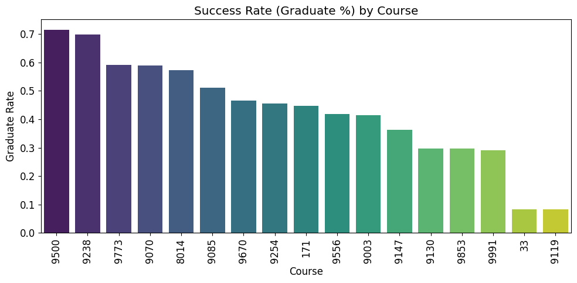

```
Top 5 Courses with Highest Success Rate:
   Course   Success
11   9500  0.715405
9    9238  0.698592
14   9773  0.592145
4    9070  0.588496
2    8014  0.572093
```

```python
# Success rate (Graduate %) by Course
success_rate = (
    data.assign(Success=(data['Target'] == 'Graduate').astype(int))
    .groupby('Course', as_index=False)['Success'].mean()
    .sort_values('Success', ascending=False)
)

plt.figure(figsize=(10,5))
sns.barplot(x='Course', y='Success', data=success_rate, hue = 'Course', palette='viridis')
plt.title('Success Rate (Graduate %) by Course')
plt.xlabel('Course')
plt.ylabel('Graduate Rate')
plt.xticks(rotation=90)
plt.tight_layout()
plt.show()

print("Top 5 Courses with Highest Success Rate:")
print(success_rate.head(5))
```

## 📘 Average Grade by Course

This bar chart shows the **average grades** of students in each major.

- Higher averages = easier or better-supported majors.
- Lower averages = more challenging programs.

By comparing this with the dropout graph, we can pinpoint **which majors are hardest** (low grades + high dropout).

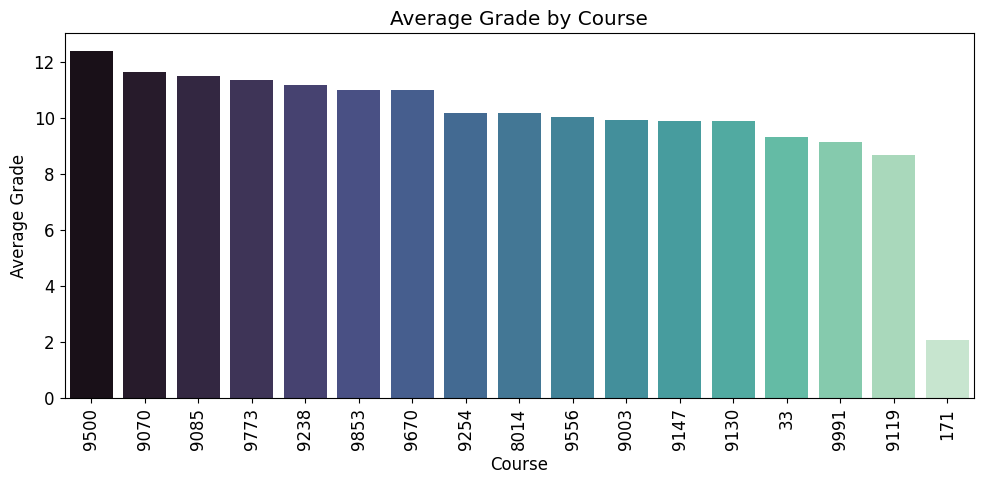

```python
# Average grades (difficulty indicator)
grade_difficulty = (
    data.groupby('Course')[['Curricular units 1st sem (grade)', 'Curricular units 2nd sem (grade)']]
    .mean()
    .reset_index()
)

grade_difficulty['Average Grade'] = grade_difficulty[
    ['Curricular units 1st sem (grade)', 'Curricular units 2nd sem (grade)']
].mean(axis=1)

plt.figure(figsize=(10,5))
sns.barplot(x='Course', y='Average Grade', hue='Course' , data=grade_difficulty.sort_values('Average Grade', ascending=False), palette='mako')
plt.title('Average Grade by Course')
plt.xlabel('Course')
plt.ylabel('Average Grade')
plt.xticks(rotation=90)
plt.tight_layout()
plt.show()
```

## 💰 GDP Distribution by Course

This boxplot shows how **GDP** varies across different majors.

- The **center line** inside each box is the median GDP value.
- Taller boxes = greater variation in GDP for that major.
- Majors with **higher median GDP** may be linked to stronger economic performance or higher-paying fields.

This helps connect academic majors to possible **economic outcomes**.

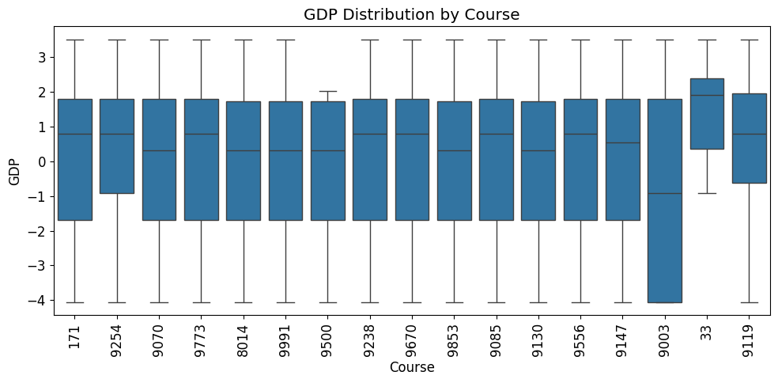

```python
plt.figure(figsize=(10,5))
sns.boxplot(x='Course', y='GDP', data=data)
plt.title('GDP Distribution by Course')
plt.xlabel('Course'); plt.ylabel('GDP')
plt.xticks(rotation=90); plt.tight_layout(); plt.show()
```

## 📉 Unemployment Rate by Course

This plot shows the **unemployment rate** for students in each course.

- Lower median unemployment = better job placement or demand for that major.
- Higher unemployment = oversaturated job markets or less employability.

Together with GDP, this helps us understand **job market demand** by major.

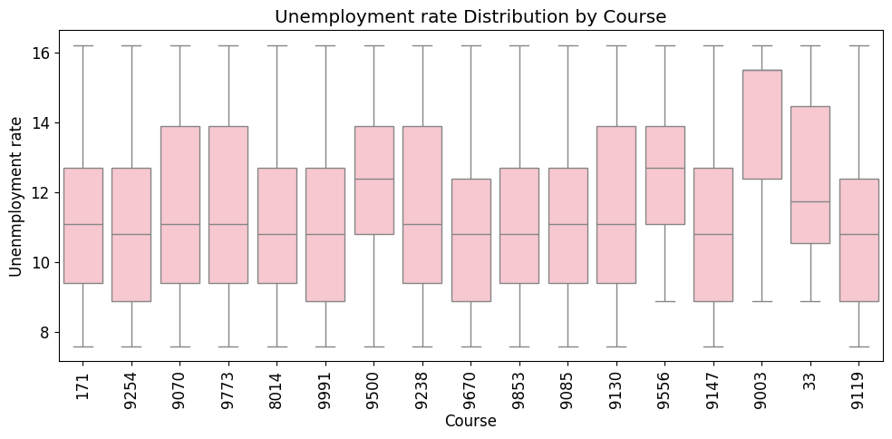

```python
#visualizing the unempoyment rate by course/major
plt.figure(figsize=(10, 5))
sns.boxplot(x='Course', y='Unemployment rate', data=data, color= "pink")
plt.title('Unemployment rate Distribution by Course')
plt.xlabel('Course')
plt.ylabel('Unenmployment rate')
plt.xticks(rotation=90)
plt.tight_layout()
plt.show()
```

## 🚪 Dropout Rate by Course

Here we calculate and visualize the **dropout percentage** for each major.

- Higher bars = more students dropping out.
- Lower bars = more students completing the course.

This graph helps identify **majors that are academically or structurally difficult**, answering which programs may need additional support.

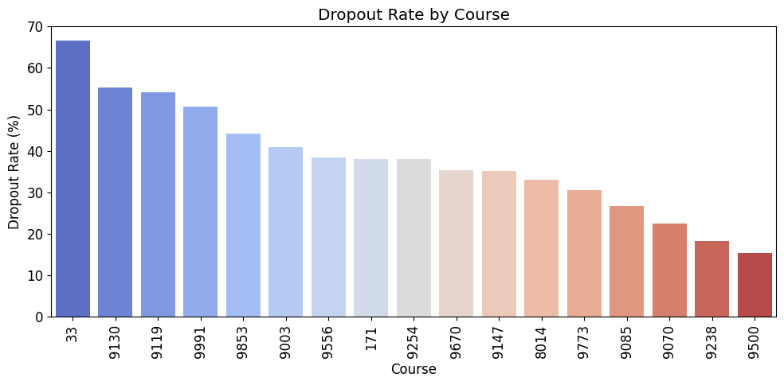

```
Top 5 Courses with Highest Success Rate:
   Course  Dropout Rate
1      33      0.666667
7    9130      0.553191
6    9119      0.541176
16   9991      0.507463
15   9853      0.442708
```

```python
dropout_rate = (
    data.assign(Dropout=(data['Target'] == 'Dropout').astype(int))
        .groupby('Course', as_index=False)['Dropout'].mean()
        .rename(columns={'Dropout': 'Dropout Rate'})
        .sort_values('Dropout Rate', ascending=False)
)

dropout_data = data[data['Target'] == 'Dropout']
dropout_counts = dropout_data['Course'].value_counts().reset_index()
dropout_counts.columns = ['Course', 'Dropout Count']
total_counts = data['Course'].value_counts().reset_index()
total_counts.columns = ['Course', 'Total Count']
merged_counts = pd.merge(dropout_counts, total_counts, on='Course', how='right').fillna(0)
merged_counts['Dropout Rate (%)'] = (merged_counts['Dropout Count'] / merged_counts['Total Count']) * 100

plt.figure(figsize=(10, 5))
sns.barplot(x='Course', y='Dropout Rate (%)', hue='Course', data=merged_counts.sort_values('Dropout Rate (%)', ascending=False), palette='coolwarm')
plt.title('Dropout Rate by Course')
plt.xlabel('Course')
plt.ylabel('Dropout Rate (%)')
plt.xticks(rotation=90)
plt.tight_layout()
plt.show()

print("Top 5 Courses with Highest Success Rate:")
print(dropout_rate.head(5))
```

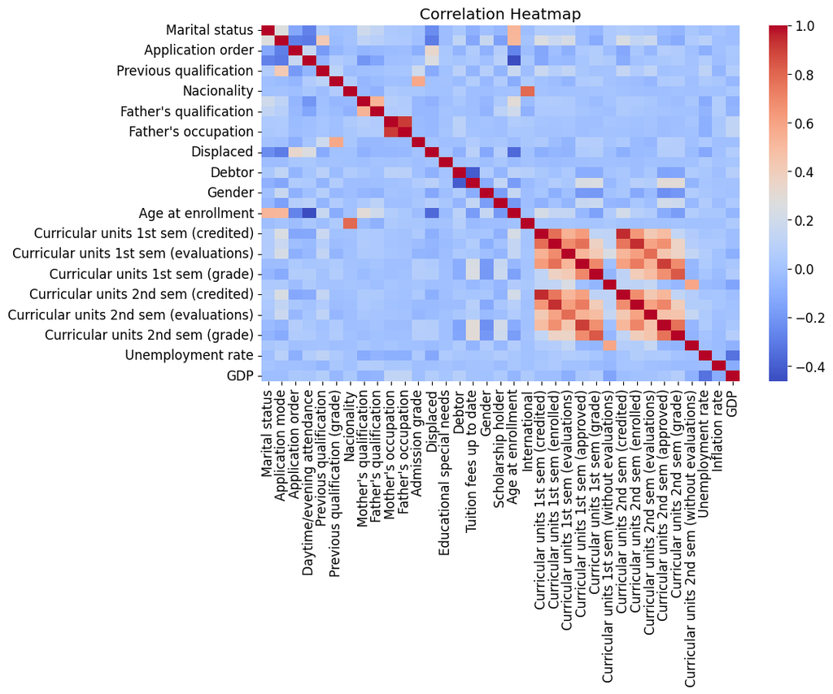

```python
corr = data.select_dtypes(include=np.number).corr()
plt.figure(figsize=(10, 6))
sns.heatmap(corr, annot=False, cmap='coolwarm')
plt.title('Correlation Heatmap')
plt.show()
```